# Lab 1: Benchmarks and Exponential Smoothing

ECON 8310: Business Forecasting — University of Nebraska at Omaha

# What we are doing

Lecture 1 made a claim that sounded like housekeeping: **always beat a benchmark first**. In the next 35 minutes you are going to test that claim on a real Walmart series, and then watch it fail on a different one.

The business question: you are forecasting weekly HOUSEHOLD-goods demand at store TX_1 to set inventory a year out. Which method should you actually ship?

**Suggested time:** ~35 minutes · **You will need:** `pandas`, `numpy`, `matplotlib`, `statsmodels`, and `data/processed/m5_weekly.csv` (run `python scripts/prep_m5.py` if it is missing).

# Setup

Nothing to fill in here — run it and move on.

```python
import pandas as pd
import numpy as np
import matplotlib.pyplot as plt
from statsmodels.tsa.holtwinters import ExponentialSmoothing, SimpleExpSmoothing, Holt
import warnings
warnings.filterwarnings('ignore')

from pathlib import Path

def data_path(name):
    """Find the processed data file whether you render from the repo root or from
    this file's own folder."""
    for base in (Path.cwd(), *Path.cwd().parents):
        p = base / "data" / "processed" / name
        if p.exists():
            return p
    raise FileNotFoundError(
        f"Could not find data/processed/{name}. "
        "Run `python scripts/prep_m5.py` from the repository root first."
    )

weekly = pd.read_csv(data_path("m5_weekly.csv"), parse_dates=["week_start"])

def get_series(store, cat):
    return (weekly[(weekly.store_id == store) & (weekly.cat_id == cat)]
            .set_index("week_start")["units"].sort_index().astype(float))

y = get_series("TX_1", "HOUSEHOLD")

N_TEST = 52
train, test = y.iloc[:-N_TEST], y.iloc[-N_TEST:]
print(f"{len(y)} weeks total — train {len(train)}, test {len(test)}")
```

```
277 weeks total — train 225, test 52
```

# Step 1 — Look at it first

Never fit anything before you have seen the series.

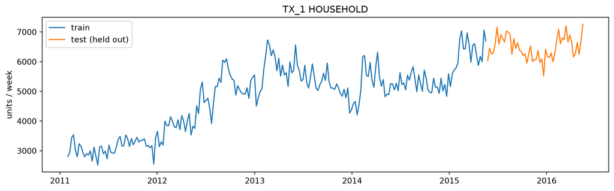

```python
fig, ax = plt.subplots(figsize=(11, 3.5))
ax.plot(train.index, train.values, label="train", lw=1.4)
ax.plot(test.index, test.values, label="test (held out)", lw=1.4)
ax.set_ylabel("units / week"); ax.set_title("TX_1 HOUSEHOLD")
ax.legend(); plt.tight_layout()
```

**Notice:** the series roughly doubles over five years, and the level is still moving at the end. Hold that thought — it is the whole lab.

# Step 2 — Establish the benchmark

Before any model, the thing to beat. **Seasonal naive** says: this week next year looks like this week last year.

```python
def rmse(actual, pred):
    return float(np.sqrt(np.mean((np.asarray(actual) - np.asarray(pred)) ** 2)))

def mae(actual, pred):
    return float(np.mean(np.abs(np.asarray(actual) - np.asarray(pred))))

seasonal_naive = y.shift(52).iloc[-N_TEST:].values

results = {"Seasonal naive": (rmse(test, seasonal_naive), mae(test, seasonal_naive))}
print(f"Seasonal naive  RMSE {results['Seasonal naive'][0]:,.0f}")
```

```
Seasonal naive  RMSE 973
```

**Your turn:** before running anything else, write down a number — what RMSE do you think a proper exponential smoothing model will get? You will check it in Step 4.

# Step 3 — Fit the three models

All three calls come straight from Lecture 1. Run this, then **predict the ordering before you look at Step 4** — write your guess down.

```python
# SES — level only.
ses_fit = SimpleExpSmoothing(train).fit()
results["SES"] = (rmse(test, ses_fit.forecast(N_TEST)),
                  mae(test, ses_fit.forecast(N_TEST)))

# Holt — level + trend. Undamped for now; we come back to damping in Step 5.
holt_fit = Holt(train).fit()
results["Holt"] = (rmse(test, holt_fit.forecast(N_TEST)),
                   mae(test, holt_fit.forecast(N_TEST)))

# Holt-Winters — level + trend + seasonality, additive, period 52.
hw_fit = ExponentialSmoothing(train, trend="add",
                              seasonal="add", seasonal_periods=52).fit()
results["Holt-Winters"] = (rmse(test, hw_fit.forecast(N_TEST)),
                           mae(test, hw_fit.forecast(N_TEST)))
```

**One constraint to respect**

Holt-Winters must estimate a seasonal index for each of the 52 weeks, and it needs **two full cycles** — 104 observations — to initialize. You have 225 training weeks, so you are fine here. You will not always be.

# Step 4 — Compare honestly

```python
tbl = (pd.DataFrame(results, index=["RMSE", "MAE"]).T
         .sort_values("RMSE").round(0).astype(int))
print(tbl.to_string())
```

```
                RMSE   MAE
SES              427   352
Holt-Winters     885   814
Seasonal naive   973   848
Holt            1166  1029
```

**Stop before reading on:** did any model beat the benchmark? By how much? And was it the model you expected in Step 2?

*In the room:* say your answer to the person next to you, and make them say theirs.  
*On your own:* score yourself against what you already wrote down. Scroll back to the RMSE number from Step 2 and the ordering from Step 3, and write two lines in a comment:

```
# guess ____, actual ____, off by ____
# ordering: right / wrong — first model I misplaced was ____
```

Grading your own prediction in writing is the part that matters. It is what makes the next result inform you rather than just agree with you.

# Step 5 — Break it, then fix it

Look at where Holt’s forecast goes.

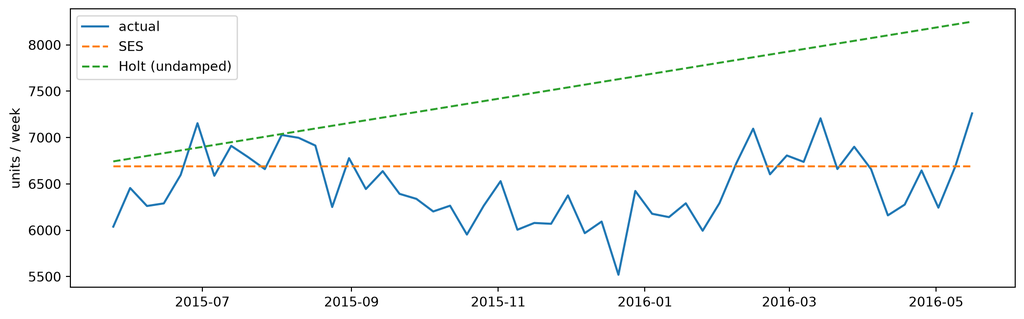

```python
fig, ax = plt.subplots(figsize=(11, 3.5))
ax.plot(test.index, test.values, label="actual", lw=1.6)
ax.plot(test.index, ses_fit.forecast(N_TEST), label="SES", ls="--")
ax.plot(test.index, holt_fit.forecast(N_TEST), label="Holt (undamped)", ls="--")
ax.set_ylabel("units / week"); ax.legend(); plt.tight_layout()
```

Lecture 1 warned that undamped linear extrapolation gets unrealistic past about six periods. You are forecasting **52**.

**Your turn:** refit Holt with a damped trend and add it to the table. One keyword argument.

```python
# ---- your turn: uncomment and fill in the one keyword argument ----
# holt_damped = Holt(train, ___).fit()             # <- damped_trend=True
#
# results["Holt (damped)"] = (rmse(test, holt_damped.forecast(N_TEST)),
#                             mae(test, holt_damped.forecast(N_TEST)))
#
# print(pd.DataFrame(results, index=["RMSE", "MAE"]).T
#         .sort_values("RMSE").round(0).astype(int).to_string())
# print(f"estimated phi: {holt_damped.params['damping_trend']:.3f}")
```

Report the value of $\phi$. What does it mean that it came out below 1?

# Step 6 — Same store. Different aisle. Opposite answer.

Change one word — `HOUSEHOLD` becomes `FOODS`. Same store, same code, same horizon.

```python
y2 = get_series("TX_1", "FOODS")
train2, test2 = y2.iloc[:-N_TEST], y2.iloc[-N_TEST:]

sn2 = y2.shift(52).iloc[-N_TEST:].values
ses2 = SimpleExpSmoothing(train2).fit()

print(f"TX_1 FOODS   seasonal naive RMSE {rmse(test2, sn2):,.0f}")
print(f"TX_1 FOODS   SES            RMSE {rmse(test2, ses2.forecast(N_TEST)):,.0f}")
```

```
TX_1 FOODS   seasonal naive RMSE 1,308
TX_1 FOODS   SES            RMSE 1,474
```

**Notice:** the ranking flips. On the household aisle an exponential smoother won comfortably. On the food aisle of the *same store*, the benchmark wins and SES is about 13% worse.

The reason is visible in one number. For TX_1 HOUSEHOLD the test year sits about **15% above** the year before it, so seasonal naive carries a stale level forward and loses badly. For TX_1 FOODS the level barely moves — about **1.5% down** — and last year is an excellent guess.

So it is not the store, and it is not the method. It is whether the level moved.

# Before you leave

> **Discuss:** You now have two series where the best method is different. You are responsible for all 30 series in this dataset and you have to pick **one** approach to run in production every month.

> What do you actually do — and what would you need to measure to decide? “Fit everything and pick the winner per series” is an answer, but say what it costs you.

*Solutions posted to Canvas after class.*